# IODS course project

# Logistic regression (week 3)

```r
date()
```

```
## [1] "Mon Nov 22 08:35:24 2021"
```

```r
library(dplyr)
```

```r
library(ggplot2)
library(ggpubr)
library(tidyr)
library(GGally)
library(boot)
```

## Read data

```r
setwd('//ad.helsinki.fi/home/z/zhangdon/Desktop/Introduction to open data science/IODS-project/data')

alc <- read.table("alc.txt", sep=",", header=TRUE, stringsAsFactors = T)

str(alc)
```

```
## 'data.frame':    370 obs. of  50 variables:
##  $ school       : Factor w/ 2 levels "GP","MS": 1 1 1 1 1 1 1 1 1 1 ...
##  $ sex          : Factor w/ 2 levels "F","M": 1 1 1 1 1 2 2 1 2 2 ...
##  $ age          : int  18 17 15 15 16 16 16 17 15 15 ...
##  $ address      : Factor w/ 2 levels "R","U": 2 2 2 2 2 2 2 2 2 2 ...
##  $ famsize      : Factor w/ 2 levels "GT3","LE3": 1 1 2 1 1 2 2 1 2 1 ...
##  $ Pstatus      : Factor w/ 2 levels "A","T": 1 2 2 2 2 2 2 1 1 2 ...
##  $ Medu         : int  4 1 1 4 3 4 2 4 3 3 ...
##  $ Fedu         : int  4 1 1 2 3 3 2 4 2 4 ...
##  $ Mjob         : Factor w/ 5 levels "at_home","health",..: 1 1 1 2 3 4 3 3 4 3 ...
##  $ Fjob         : Factor w/ 5 levels "at_home","health",..: 5 3 3 4 3 3 3 5 3 3 ...
##  $ reason       : Factor w/ 4 levels "course","home",..: 1 1 3 2 2 4 2 2 2 2 ...
##  $ guardian     : Factor w/ 3 levels "father","mother",..: 2 1 2 2 1 2 2 2 2 2 ...
##  $ traveltime   : int  2 1 1 1 1 1 1 2 1 1 ...
##  $ studytime    : int  2 2 2 3 2 2 2 2 2 2 ...
```

[output cut: 36 more lines]

```r
dim(alc)
```

```
## [1] 370  50
```

```r
print(colnames(alc))
```

```
##  [1] "school"        "sex"           "age"           "address"
##  [5] "famsize"       "Pstatus"       "Medu"          "Fedu"
##  [9] "Mjob"          "Fjob"          "reason"        "guardian"
## [13] "traveltime"    "studytime"     "failures.math" "schoolsup"
## [17] "famsup"        "paid.math"     "activities"    "nursery"
## [21] "higher"        "internet"      "romantic"      "famrel"
## [25] "freetime"      "goout"         "Dalc"          "Walc"
## [29] "health"        "absences.math" "G1.math"       "G2.math"
## [33] "G3.math"       "id.math"       "failures.por"  "paid.por"
## [37] "absences.por"  "G1.por"        "G2.por"        "G3.por"
## [41] "id.por"        "failures"      "paid"          "absences"
## [45] "G1"            "G2"            "G3"            "alc_use"
## [49] "high_use"      "cid"
```

This data is the joint data sets merging Math course with Portuguese language course. To examine the alcohol consumption with other variables, *alc_use* is the average of the workday alcohol consumption and weekend alcohol consumption. *high_use* is **TRUE** when *alc_use* is higher than 2, otherwise is **FALSE**. For some of abbreviation, *famrel* is quality of family relationships, *freetime* is the free time after school, *goout* is going out with friends. Their values are ranging from 1 vary low to 5 very high. *famsup* is the boolean value which represents if the student could get the family educational support.

## Choose the variables

Initially, it is hypothesized that family and entertainment are the key factors, which would impact the alcohol consumption of students. Thus, *famrel*, *famsup* and *freetime*, *goout* are chose for the logistic regression analysis.

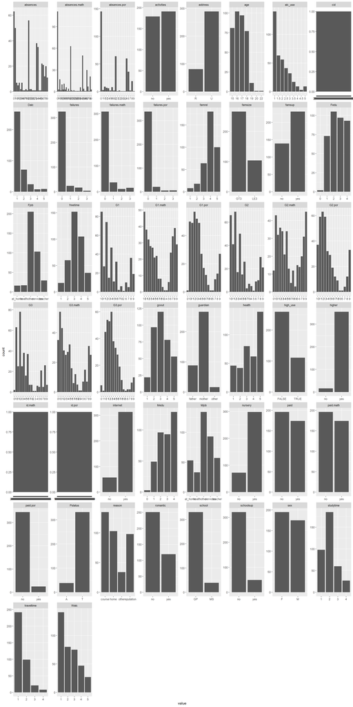

```r
gather(alc) %>% ggplot(aes(value)) + facet_wrap("key", scales = "free") + geom_bar()
```

From the Key-value pairs result, most of students are aged from 15 to 18 years old. The legal drinking age is usually over 18 in many countries. Those who under 18 years-old consumed much alcohol is largely influenced by their family or their peers.

## Exploration of the variables

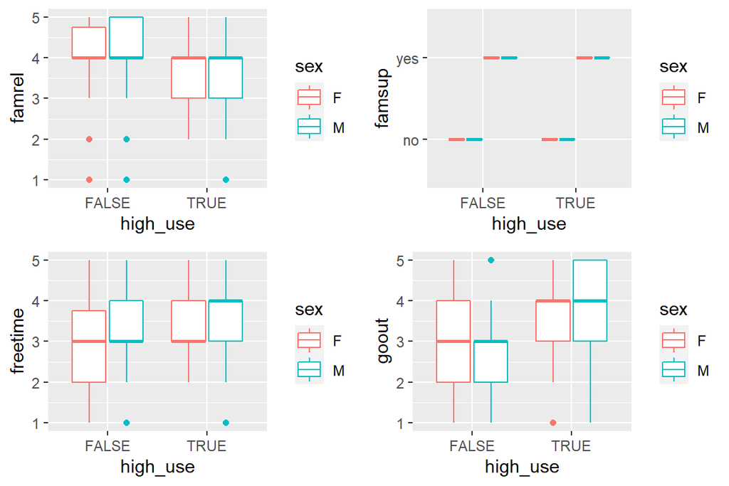

```r
famrel1 <- ggplot(alc, aes(x = high_use, y = famrel, col = sex)) + geom_boxplot()
famsup1 <- ggplot(alc, aes(x = high_use, y = famsup, col = sex)) + geom_boxplot()
freetime1 <- ggplot(alc, aes(x = high_use, y = freetime, col = sex)) + geom_boxplot()
goout1 <- ggplot(alc, aes(x = high_use, y = goout, col = sex)) + geom_boxplot()

ggarrange(famrel1, famsup1, freetime1, goout1,
          ncol = 2, nrow = 2)
```

Observing the family relationships with high_use, most of high_use students also have a good relations with family members. Just looking into the boxplots, boys have more free time than girls so they might like to drink much more. For those who go out with friends more times per week, they are easily drunk much more. Because family educational support is the Boolean values, it is not clear just observing from the box plots.

```r
alc %>% group_by(famrel, high_use) %>% summarise(count = n())
```

```
## # A tibble: 10 x 3
## # Groups:   famrel [5]
##    famrel high_use count
##     <int> <lgl>    <int>
##  1      1 FALSE        6
##  2      1 TRUE         2
##  3      2 FALSE        9
##  4      2 TRUE         9
##  5      3 FALSE       39
##  6      3 TRUE        25
##  7      4 FALSE      128
##  8      4 TRUE        52
##  9      5 FALSE       77
## 10      5 TRUE        23
```

```r
alc %>% group_by(famsup, high_use) %>% summarise(count = n())
```

```
## # A tibble: 4 x 3
## # Groups:   famsup [2]
##   famsup high_use count
##   <fct>  <lgl>    <int>
## 1 no     FALSE       94
## 2 no     TRUE        45
## 3 yes    FALSE      165
## 4 yes    TRUE        66
```

```r
alc %>% group_by(freetime, high_use) %>% summarise(count = n())
```

```
## # A tibble: 10 x 3
## # Groups:   freetime [5]
##    freetime high_use count
##       <int> <lgl>    <int>
##  1        1 FALSE       15
##  2        1 TRUE         2
##  3        2 FALSE       46
##  4        2 TRUE        14
##  5        3 FALSE      112
##  6        3 TRUE        40
##  7        4 FALSE       65
##  8        4 TRUE        40
##  9        5 FALSE       21
## 10        5 TRUE        15
```

```r
alc %>% group_by(goout, high_use) %>% summarise(count = n())
```

```
## # A tibble: 10 x 3
## # Groups:   goout [5]
##    goout high_use count
##    <int> <lgl>    <int>
##  1     1 FALSE       19
##  2     1 TRUE         3
##  3     2 FALSE       82
##  4     2 TRUE        15
##  5     3 FALSE       97
##  6     3 TRUE        23
##  7     4 FALSE       40
##  8     4 TRUE        38
##  9     5 FALSE       21
## 10     5 TRUE        32
```

## Logistic regression model

```r
m <- glm(high_use ~ famrel + famsup + freetime + goout, data = alc, family = "binomial")

summary(m)
```

```
##
## Call:
## glm(formula = high_use ~ famrel + famsup + freetime + goout,
##     family = "binomial", data = alc)
##
## Deviance Residuals:
##     Min       1Q   Median       3Q      Max
## -1.7364  -0.7799  -0.5596   0.9979   2.4376
##
## Coefficients:
##             Estimate Std. Error z value Pr(>|z|)
## (Intercept)  -2.1950     0.6982  -3.144  0.00167 **
## famrel       -0.4191     0.1371  -3.056  0.00224 **
## famsupyes    -0.1900     0.2542  -0.747  0.45482
## freetime      0.2014     0.1364   1.477  0.13966
## goout         0.7405     0.1233   6.006  1.9e-09 ***
## ---
## Signif. codes:  0 '***' 0.001 '**' 0.01 '*' 0.05 '.' 0.1 ' ' 1
##
## (Dispersion parameter for binomial family taken to be 1)
##
##     Null deviance: 452.04  on 369  degrees of freedom
## Residual deviance: 391.89  on 365  degrees of freedom
## AIC: 401.89
##
## Number of Fisher Scoring iterations: 4
```

```r
coef(m)
```

```
## (Intercept)      famrel   famsupyes    freetime       goout
##  -2.1949968  -0.4191495  -0.1899943   0.2014051   0.7405345
```

From the summary results of the model, family relationships and go out times are significantly influence the high alcohol consumption in students. Go out times is the most significant factor, that is 1.9e-09. Family educational support and free time are not significant according to the results. The coefficient values of model is similar to the estimate values from summary function. family relationships and family educational support are minus value (-0.4191 and -0.1899), which means that they are negative associated with the target variable (high alcohol consumption). Whereas free time and go out are the positive associated with target variable, 0.2014 and 0.74005, respectively.

## Odds ratios and confidence intervals

```r
OR <- coef(m) %>% exp
CI <- confint(m) %>% exp
cbind(OR, CI)
```

```
##                    OR     2.5 %    97.5 %
## (Intercept) 0.1113589 0.0272651 0.4247412
## famrel      0.6576059 0.5006796 0.8588025
## famsupyes   0.8269639 0.5027027 1.3646341
## freetime    1.2231201 0.9373983 1.6021304
## goout       2.0970561 1.6575495 2.6907078
```

```r
m1 <- glm(high_use ~ famrel + famsup + freetime + goout - 1, data = alc, family = "binomial")

summary(m1)
```

```
##
## Call:
## glm(formula = high_use ~ famrel + famsup + freetime + goout -
##     1, family = "binomial", data = alc)
##
## Deviance Residuals:
##     Min       1Q   Median       3Q      Max
## -1.7364  -0.7799  -0.5596   0.9979   2.4376
##
## Coefficients:
##           Estimate Std. Error z value Pr(>|z|)
## famrel     -0.4191     0.1371  -3.056 0.002241 **
## famsupno   -2.1950     0.6982  -3.144 0.001668 **
## famsupyes  -2.3850     0.6818  -3.498 0.000469 ***
## freetime    0.2014     0.1364   1.477 0.139657
## goout       0.7405     0.1233   6.006  1.9e-09 ***
## ---
## Signif. codes:  0 '***' 0.001 '**' 0.01 '*' 0.05 '.' 0.1 ' ' 1
##
## (Dispersion parameter for binomial family taken to be 1)
##
##     Null deviance: 512.93  on 370  degrees of freedom
## Residual deviance: 391.89  on 365  degrees of freedom
## AIC: 401.89
##
## Number of Fisher Scoring iterations: 4
```

```r
coef(m1)
```

```
##     famrel   famsupno  famsupyes   freetime      goout
## -0.4191495 -2.1949968 -2.3849911  0.2014051  0.7405345
```

```r
m2  <- glm(high_use ~ famrel + famsup + goout, data = alc, family = "binomial")
m3  <- glm(high_use ~ famrel + freetime +goout, data = alc, family = "binomial")

anova(m, m2, test = 'LRT')
```

```
## Analysis of Deviance Table
##
## Model 1: high_use ~ famrel + famsup + freetime + goout
## Model 2: high_use ~ famrel + famsup + goout
##   Resid. Df Resid. Dev Df Deviance Pr(>Chi)
## 1       365     391.89
## 2       366     394.09 -1  -2.1989   0.1381
```

```r
anova(m, m3, test = 'LRT')
```

```
## Analysis of Deviance Table
##
## Model 1: high_use ~ famrel + famsup + freetime + goout
## Model 2: high_use ~ famrel + freetime + goout
##   Resid. Df Resid. Dev Df Deviance Pr(>Chi)
## 1       365     391.89
## 2       366     392.45 -1 -0.55693   0.4555
```

According to the analysis of model with and without free time, the likelihood ratio test is 0.1381, which is not significant to the model. Also, comparing with the models containing family support or not, the likelihood ratio test Free time is 0.4555. Free time and family support are not the significant factors influencing the high alcohol consumption of students. Thus, both of them can be removed from the logistic regression model for increasing the accuracy of prediction.

## Prediction validation and loss functions

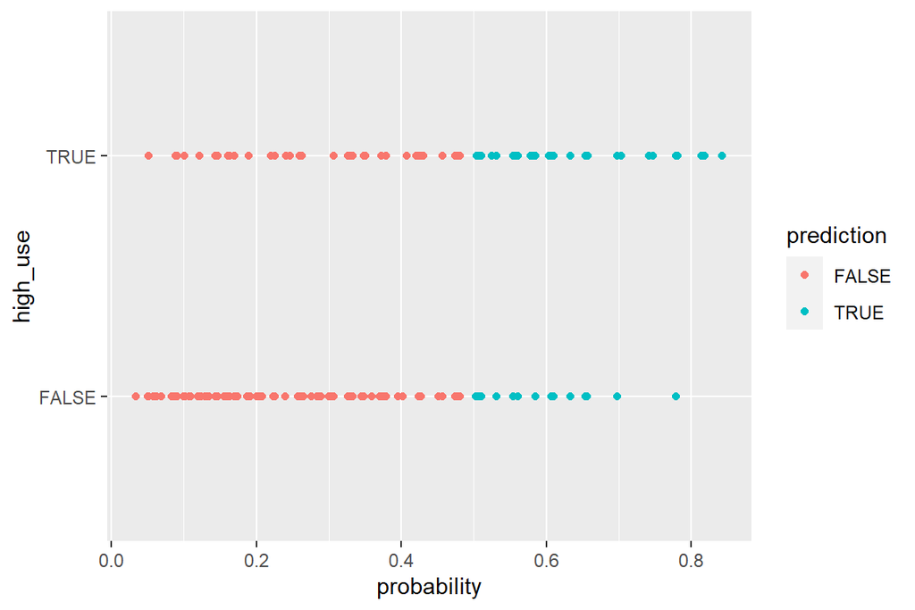

```r
probabilities <- predict(m, type = "response")

alc0 <- mutate(alc, probability = probabilities) %>% mutate(alc, prediction = probabilities > 0.5)

g <- ggplot(alc0, aes(x = probability, y = high_use, col = prediction))

g + geom_point()
```

At first, the initial four variables (family relationships, family educational support, free time and go out) are used for logistic regression and the whole data is used for the predication validation. From the plot, the points of negative false seems larger than negative true. So, the exact prediction results should be examined by the table function.

```r
select(alc0, age, freetime, failures, goout, high_use, probability, prediction) %>% tail(10)
```

```
##     age freetime failures goout high_use probability prediction
## 361  17        4        0     3    FALSE  0.30061496      FALSE
## 362  19        3        1     2    FALSE  0.14352564      FALSE
## 363  18        4        1     3     TRUE  0.22036842      FALSE
## 364  18        3        0     3    FALSE  0.18771510      FALSE
## 365  18        4        0     3    FALSE  0.26223864      FALSE
## 366  19        4        1     2    FALSE  0.11877781      FALSE
## 367  18        3        0     4    FALSE  0.37866087      FALSE
## 368  18        1        0     1    FALSE  0.15813018      FALSE
## 369  17        4        0     5     TRUE  0.81381569       TRUE
## 370  18        4        0     1     TRUE  0.08903782      FALSE
```

```r
table(high_use = alc0$high_use, prediction = alc0$prediction)
```

```
##         prediction
## high_use FALSE TRUE
##    FALSE   237   22
##    TRUE     72   39
```

```r
table(high_use = alc0$high_use, prediction = alc0$prediction) %>% prop.table() %>% addmargins()
```

```
##         prediction
## high_use      FALSE       TRUE        Sum
##    FALSE 0.64054054 0.05945946 0.70000000
##    TRUE  0.19459459 0.10540541 0.30000000
##    Sum   0.83513514 0.16486486 1.00000000
```

As shown by the above two tables, the accuracy of prediction can be computed by (total negative false + total positive true) divided by total number of students. Thankfully, the prop.table function has computed this probability. The accuracy of the model is 0.6405 + 0.1054 equal to 0.7459. It means that the prediction accuracy of this model is 74.59%.

```r
loss_func <- function(class, prob) {
  n_wrong <- abs(class - prob) > 0.5
  mean(n_wrong)
}

loss_func(class = alc0$high_use, prob = alc0$probability)
```

```
## [1] 0.2540541
```

Loss function is a easy way for prediction validation. As shown by the above result, loss function is 0.2541, the accuracy is 0.7459 (1-0.2541). The accuracy is consistent with the above handle calculated value from the table results.

```r
m4  <- glm(high_use ~ famrel + goout, data = alc, family = "binomial")

probabilities1 <- predict(m4, type = "response")

alc1 <- mutate(alc, probability = probabilities1) %>% mutate(alc, prediction = probabilities1 > 0.5)

loss_func(class = alc1$high_use, prob = alc1$probability)
```

```
## [1] 0.2432432
```

As we see, the loss of the model (**m4**) is decreased compared to the model with all four variables (**m**), from 0.2541 to 0.2432. The accuracy of the model prediction is increased by selecting the significant factors.

## Cross validation

```r
loss_func(class = alc1$high_use, prob = alc1$probability)
```

```
## [1] 0.2432432
```

```r
cv <- cv.glm(data = alc, cost = loss_func, glmfit = m4, K = 10)
cv$delta[1]
```

```
## [1] 0.2675676
```

After cross validation, the model using 10-fold cross-validation seems not perform better than the model not using cross validation. From the values, the prediction accuracy is always larger than the loss of the initial model after cross validation. Because the data is divided into 10 parts for training and testing, the accuracy value is much reasonable by cross validation although it is relatively higher.

```r
crossvalidation <- function(model){
  cv <- cv.glm(data = alc, cost = loss_func, glmfit = model, K = 10)
  cv$delta[1]
}


accuracy <- sapply(1:100, function(n)crossvalidation(m4))

accuracy
```

```
##   [1] 0.2567568 0.2540541 0.2648649 0.2567568 0.2540541 0.2513514 0.2486486
##   [8] 0.2621622 0.2594595 0.2567568 0.2567568 0.2459459 0.2459459 0.2486486
##  [15] 0.2729730 0.2594595 0.2432432 0.2540541 0.2594595 0.2729730 0.2540541
##  [22] 0.2405405 0.2486486 0.2567568 0.2486486 0.2594595 0.2648649 0.2459459
##  [29] 0.2594595 0.2513514 0.2648649 0.2540541 0.2567568 0.2702703 0.2540541
##  [36] 0.2432432 0.2594595 0.2567568 0.2540541 0.2540541 0.2459459 0.2540541
##  [43] 0.2513514 0.2540541 0.2567568 0.2594595 0.2621622 0.2540541 0.2567568
##  [50] 0.2567568 0.2567568 0.2459459 0.2513514 0.2621622 0.2648649 0.2567568
##  [57] 0.2675676 0.2540541 0.2567568 0.2459459 0.2486486 0.2567568 0.2594595
##  [64] 0.2486486 0.2540541 0.2567568 0.2648649 0.2567568 0.2540541 0.2567568
##  [71] 0.2432432 0.2594595 0.2540541 0.2432432 0.2540541 0.2675676 0.2567568
##  [78] 0.2648649 0.2567568 0.2594595 0.2513514 0.2702703 0.2432432 0.2567568
##  [85] 0.2810811 0.2540541 0.2486486 0.2729730 0.2540541 0.2675676 0.2540541
##  [92] 0.2675676 0.2459459 0.2432432 0.2621622 0.2540541 0.2486486 0.2540541
##  [99] 0.2540541 0.2459459
```

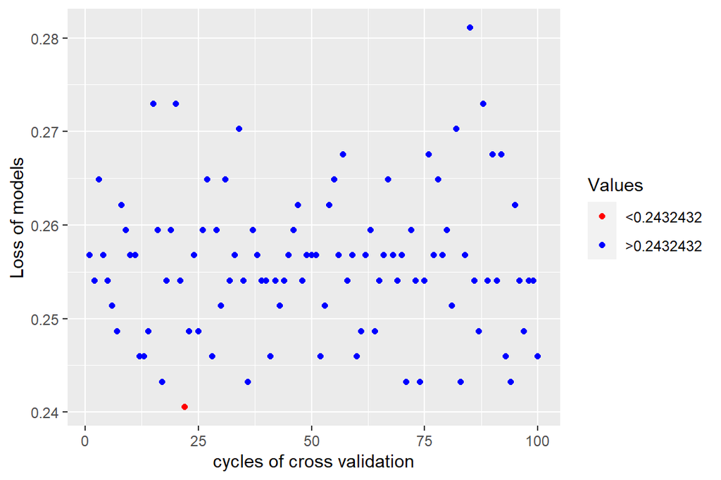

```r
v <- data.frame(accuracy)
ggplot(v, aes(x = as.numeric(row.names(v)), y = accuracy, group = as.numeric(row.names(v)))) +
  geom_point(aes(color = ifelse(accuracy>0.2432432, 'red', 'blue'))) +
  scale_colour_manual(labels = c("<0.2432432", ">0.2432432"), values=c('red', 'blue')) +
  labs(color = "Values") +labs(x = 'cycles of cross validation', y = 'Loss of models')
```

Running 100 cycles of cross validation for model, there are few values of cross validation are less than loss function value of the whole data validation. However, it demonstrates that the predication accuracy by cross validation is at a range of scale due to the random separation of training and testing parts.

To examine the trend about different numbers of predictors in the model. The ten variables are selected randomly and then change to only one variable for the logistic regression model. The cross validation results are calculated based on the different numbers of variables.

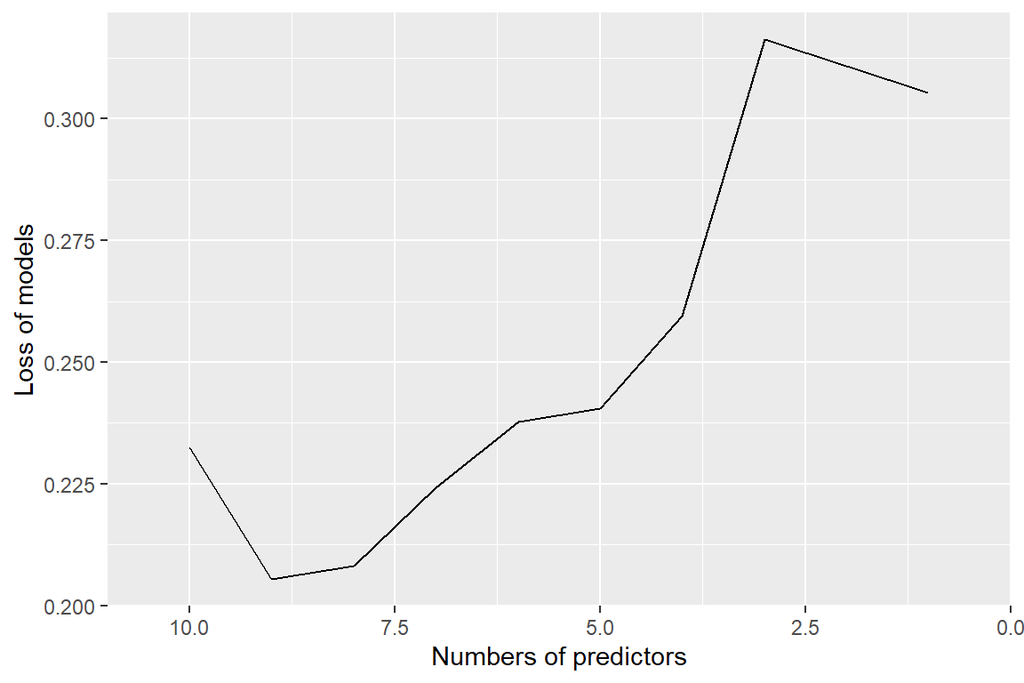

```r
# generate the models with different numbers of predictors
mm10 <- glm(high_use ~ famrel + famsup + freetime + goout + sex + age + higher + absences + failures + activities, data = alc, family = "binomial")
mm9 <- glm(high_use ~ famrel + famsup + freetime + goout + sex + age + higher + absences + failures, data = alc, family = "binomial")
mm8 <- glm(high_use ~ famrel + famsup + freetime + goout + sex + age + higher + absences, data = alc, family = "binomial")
mm7 <- glm(high_use ~ famrel + famsup + freetime + goout + sex + age + higher, data = alc, family = "binomial")
mm6 <- glm(high_use ~ famrel + famsup + freetime + goout + sex + age, data = alc, family = "binomial")
mm5 <- glm(high_use ~ famrel + famsup + freetime + goout + sex, data = alc, family = "binomial")
mm4 <- glm(high_use ~ famrel + famsup + freetime + goout, data = alc, family = "binomial")
mm3 <- glm(high_use ~ famrel + famsup + freetime, data = alc, family = "binomial")
mm2 <- glm(high_use ~ famrel + famsup, data = alc, family = "binomial")
mm1 <- glm(high_use ~ famrel, data = alc, family = "binomial")

cv10 <- c(crossvalidation(mm10), crossvalidation(mm9), crossvalidation(mm8), crossvalidation(mm7), crossvalidation(mm6), crossvalidation(mm5), crossvalidation(mm4), crossvalidation(mm3), crossvalidation(mm2), crossvalidation(mm1))

No_predictor <- 10:1

supur_bonus <- data.frame(No_predictor, cv10)

ggplot(supur_bonus, aes(x = No_predictor, y = cv10)) + geom_line() + labs(x = 'Numbers of predictors', y = 'Loss of models') + xlim(10.5, 0.5)
```

According to the above trend analysis, the few predictors, the higher loss of models. So the accuracy of the prediction depends on the numbers of variables in the model. However, more variables do not mean the better prediction accuracy, other insignificant predictors could decrease the accuracy of the logistic regression model. Searching all significant variables for the logistic regression model would be generate the most accurate prediction.

(more chapters to be added similarly as we proceed with the course!)